# Cross Validation

Jake Vettoretti

2025-11-11

Load key packages

```r
library(tidyverse)
library(modelr)
library(mgcv)
library(p8105.datasets)

set.seed(1)
```

## Cross Validation

Load LIDAR

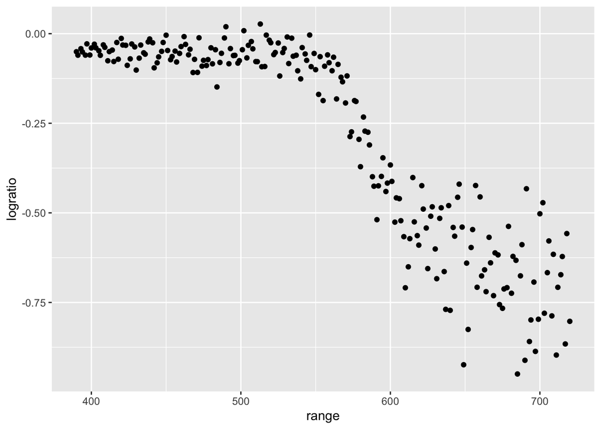

```r
data("lidar")

lidar_df =
  lidar |>
  as_tibble() |>
  mutate(id = row_number())

lidar_df |>
  ggplot(aes(x = range, y = logratio)) +
  geom_point()
```

I’ll split this data into training and test sets (using anti_join!!), and replot showing the split. Our goal will be to use the training data (in black) to build candidate models, and then see how those models predict in the testing data (in red).

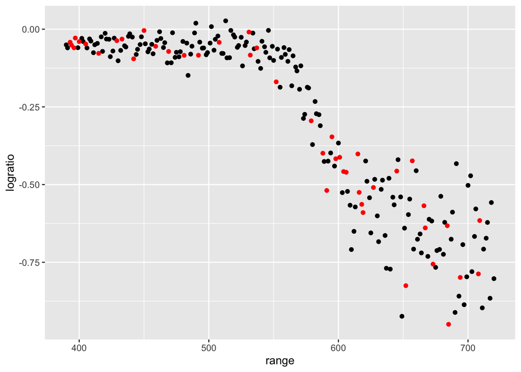

```r
train_df = sample_frac(lidar_df, size = .8)
test_df = anti_join(lidar_df, train_df, by = "id")

ggplot(train_df, aes(x = range, y = logratio)) +
  geom_point() +
  geom_point(data = test_df, color = "red")
```

Fit three three models to the training data. Throughout, I’m going to use mgcv::gam for non-linear models – this is my go-to package for “additive models”, and I much prefer it to e.g. polynomial models. For today, you don’t have to know what this means, how gam works, or why I prefer it – just know that we’re putting smooth lines through data clouds, and we can control how smooth we want the fit to be.

The three models below have very different levels of complexity and aren’t nested, so testing approaches for nested model don’t apply.

```r
linear_mod = lm(logratio ~ range, data = train_df)
smooth_mod = mgcv::gam(logratio ~ s(range), data = train_df)
wiggly_mod = mgcv::gam(logratio ~ s(range, k = 30), sp = 10e-6, data = train_df)
```

To understand what the models are doing:

Smooth

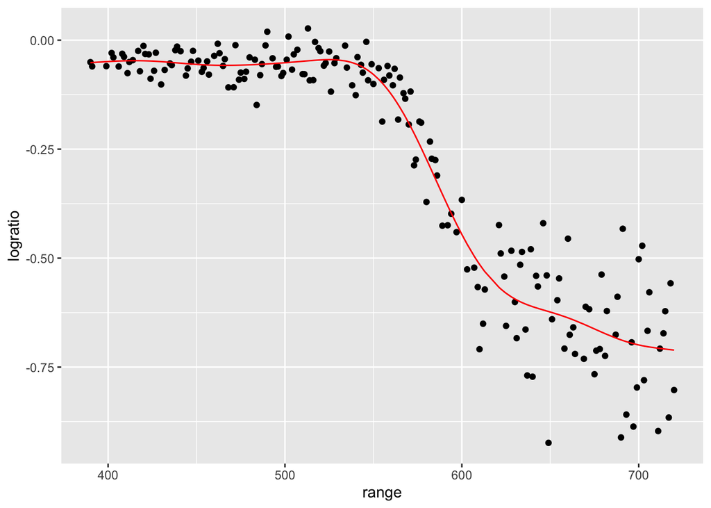

```r
train_df |>
  add_predictions(smooth_mod) |>
  ggplot(aes(x = range, y = logratio)) +
  geom_point() +
  geom_line(aes(y = pred), color = "red")
```

Wiggly

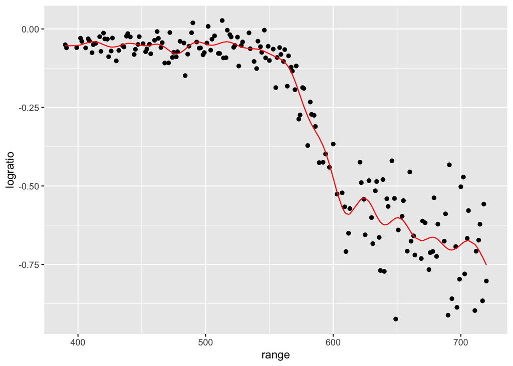

```r
train_df |>
  add_predictions(wiggly_mod) |>
  ggplot(aes(x = range, y = logratio)) +
  geom_point() +
  geom_line(aes(y = pred), color = "red")
```

I can also use the handy modelr::gather_predictions function – this is, essentially, a short way of adding predictions for several models to a data frame and then “pivoting” so the result is a tidy, “long” dataset that’s easily plottable.

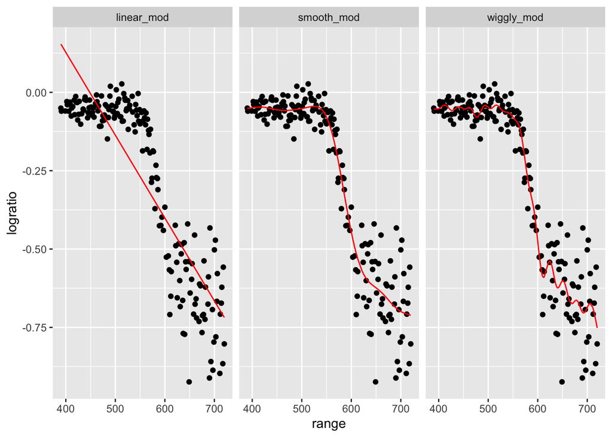

```r
train_df |>
  gather_predictions(linear_mod, smooth_mod, wiggly_mod) |>
  mutate(model = fct_inorder(model)) |>
  ggplot(aes(x = range, y = logratio)) +
  geom_point() +
  geom_line(aes(y = pred), color = "red") +
  facet_wrap(~model)
```

Try computing RMSEs

```r
rmse(linear_mod, test_df)
```

```
## [1] 0.127317
```

```r
rmse(smooth_mod, test_df)
```

```
## [1] 0.08302008
```

```r
rmse(wiggly_mod, test_df)
```

```
## [1] 0.08848557
```

## ITERATE

```r
cv_df =
  crossv_mc(lidar_df, n = 100) |>
  mutate(
    train = map(train, as_tibble),
    test = map(test, as_tibble)
  )
```

Did this work? Yes!

```r
cv_df |>  pull(train) |> nth(1)
```

```
## # A tibble: 176 × 3
##    range logratio    id
##    <dbl>    <dbl> <int>
##  1   390  -0.0504     1
##  2   394  -0.0510     4
##  3   396  -0.0599     5
##  4   399  -0.0596     7
##  5   400  -0.0399     8
##  6   402  -0.0294     9
##  7   403  -0.0395    10
##  8   405  -0.0476    11
##  9   406  -0.0604    12
## 10   408  -0.0312    13
## # ℹ 166 more rows
```

Let’s fit models over and over. Could use function too

```r
cv_df =
cv_df |>
  mutate(
    linear_fits = map(train, \(df) lm(logratio ~ range, data = df)),
    smooth_fits = map(train, \(df) mgcv::gam(logratio ~ s(range), data = df)),
    wiggly_fits = map(train, \(df) mgcv::gam(logratio ~ s(range, k=50), sp = 10e-8, data = df)),
  ) |>
  mutate( #needs both model being fit and training dataset
    rmse_linear = map2_dbl(linear_fits, test, rmse),
    rmse_smooth = map2_dbl(smooth_fits, test, rmse),
    rmse_wiggly = map2_dbl(wiggly_fits, test, rmse)
  )
```

Let’s try to view better. Care about MSE as shows model best fit

MSE: measures the average squared difference between the model’s predicted values and the actual observed values.

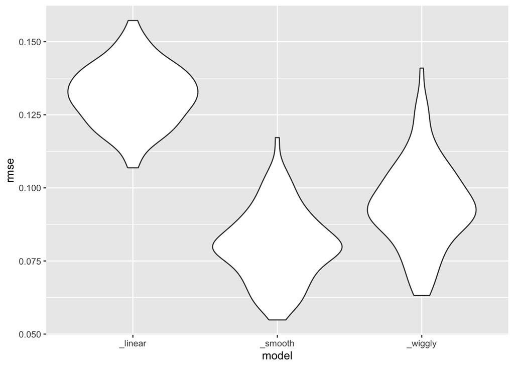

```r
cv_df |>
  select(starts_with("rmse")) |>
  pivot_longer(
    everything(),
    names_to = "model",
    values_to = "rmse",
    names_prefix = "rmse"
  ) |>
  ggplot(aes(x=model, y=rmse)) +
  geom_violin()
```

## Use real world example

```r
child_growth = read_csv("data/nepalese_children.csv")
```

Let’s show the models we might use.

```r
growth_df =
  child_growth |>
  mutate(
    weight_cp7 = (weight > 7) * (weight - 7)
  )
```

Weight vs. arm_c

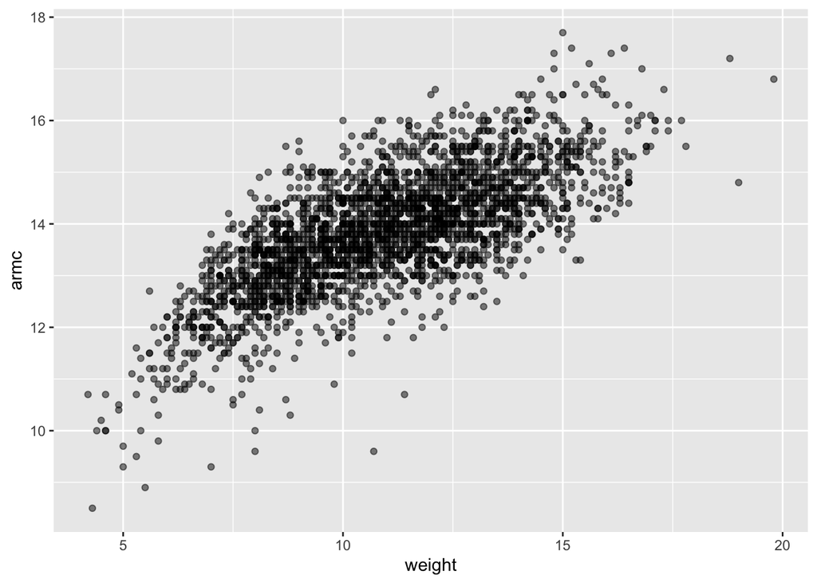

```r
child_growth |>
  ggplot(aes(x = weight, y = armc)) +
  geom_point(alpha = .5)
```

Let’s fit three models

```r
linear_mod = lm(armc ~ weight, growth_df)
pwl_mod = lm(armc ~ weight +weight_cp7, growth_df)
smooth_mod = mgcv::gam(armc ~ s(weight), data = growth_df)
```

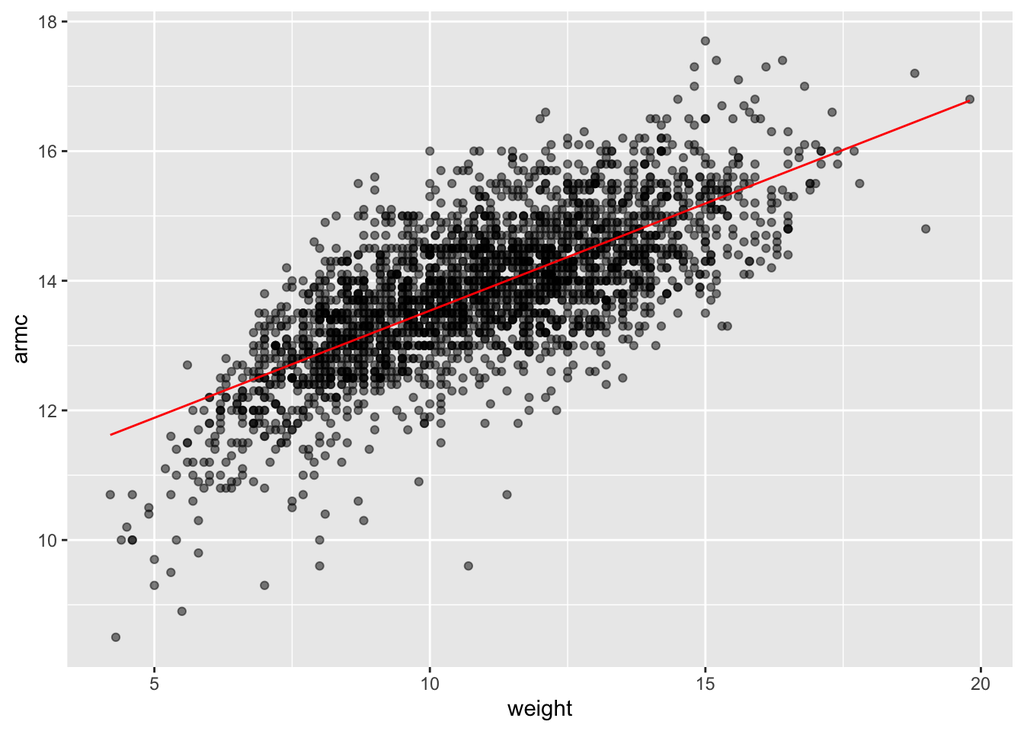

```r
growth_df |>
  add_predictions(linear_mod) |>
  ggplot(aes(x=weight, y = armc)) +
  geom_point(alpha = .5) +
  geom_line(aes(y=pred), color ="red")
```

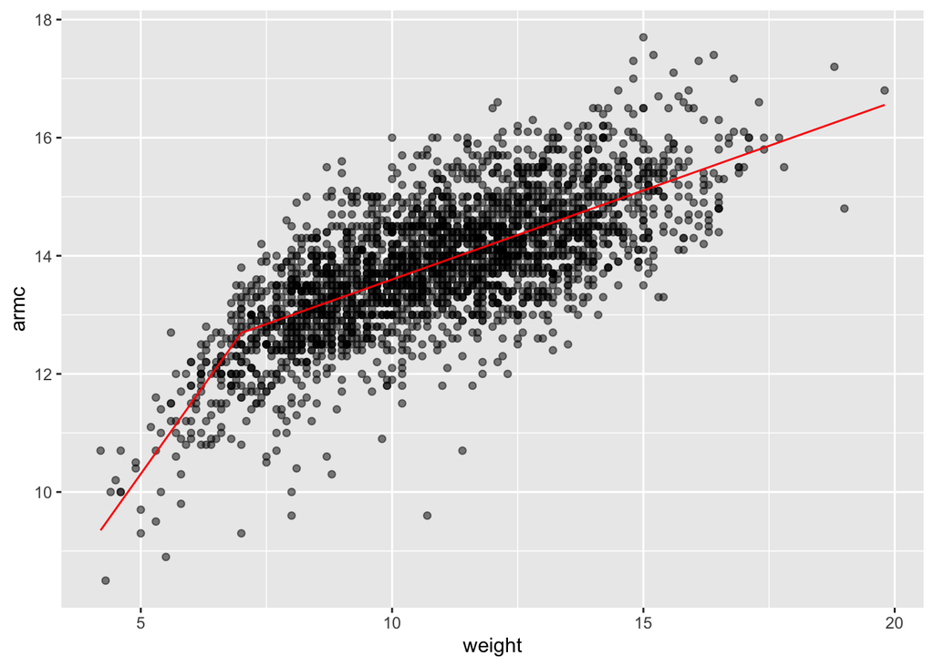

```r
growth_df |>
  add_predictions(pwl_mod) |>
  ggplot(aes(x=weight, y = armc)) +
  geom_point(alpha = .5) +
  geom_line(aes(y=pred), color ="red")
```

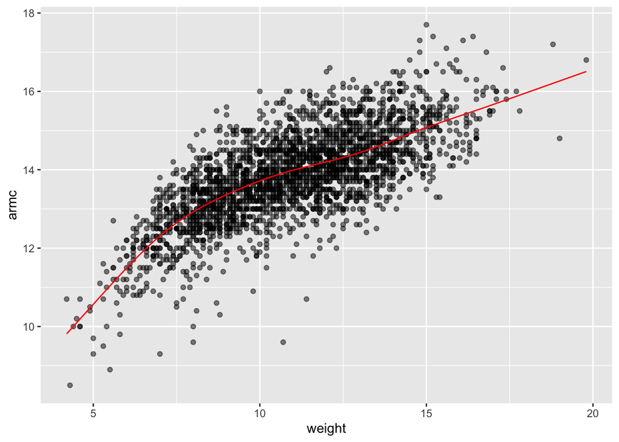

```r
growth_df |>
  add_predictions(smooth_mod) |>
  ggplot(aes(x=weight, y = armc)) +
  geom_point(alpha = .5) +
  geom_line(aes(y=pred), color ="red")
```

Now cross validate!

```r
cv_df =
  crossv_mc(growth_df, n = 100) |>
  mutate(
    train = map(train, as_tibble),
    test = map(test, as_tibble)
  )
```

```r
cv_df =
  cv_df |>
  mutate(
    linear_mod = map(train, \(df) lm(armc ~ weight, data = df)),
    pwl_mod    = map(train, \(df) lm(armc ~ weight + weight_cp7, data = df)),
    smooth_mod = map(train, \(df) mgcv::gam(armc ~ s(weight), data = df))
  ) |>
  mutate(
    rmse_linear = map2_dbl(linear_mod, test, rmse),
    rmse_pwl    = map2_dbl(pwl_mod, test, rmse),
    rmse_smooth = map2_dbl(smooth_mod, test, rmse)
  )
```

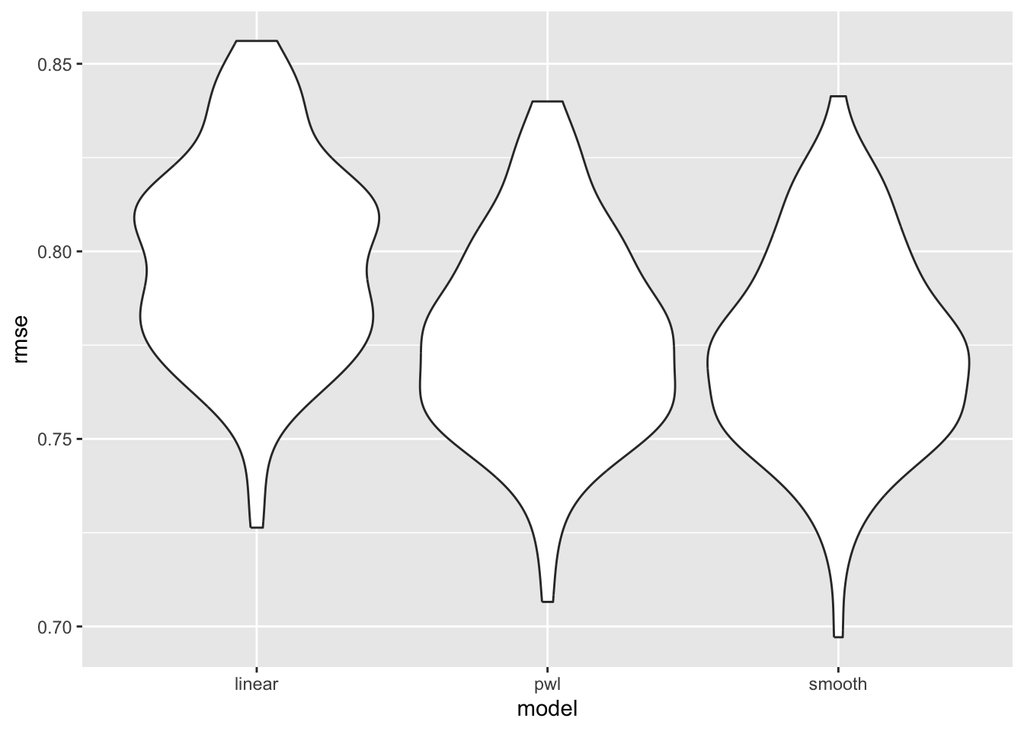

```r
cv_df |>
  select(starts_with("rmse")) |>
  pivot_longer(
    everything(),
    names_to = "model",
    values_to = "rmse",
    names_prefix = "rmse_"
  ) |>
  ggplot(aes(x = model, y = rmse)) +
  geom_violin()
```